# CMPINF 2130 Summer 2021 - Week 03

## Grouping

How can we group in `R`, or more specicially in the `tidyverse`? We use the `group_by()` function. To replicate what we did in Pandas we need to use `group_by()` and the `group_map()` function. First, let’s just see what the `group_by()` function does.

```r
iris %>%
  select(starts_with("Sepal."), Species) %>%
  group_by(Species)
```

```
## # A tibble: 150 x 3
## # Groups:   Species [3]
##    Sepal.Length Sepal.Width Species
##           <dbl>       <dbl> <fct>
##  1          5.1         3.5 setosa
##  2          4.9         3   setosa
##  3          4.7         3.2 setosa
##  4          4.6         3.1 setosa
##  5          5           3.6 setosa
##  6          5.4         3.9 setosa
##  7          4.6         3.4 setosa
##  8          5           3.4 setosa
##  9          4.4         2.9 setosa
## 10          4.9         3.1 setosa
## # ... with 140 more rows
```

The `group_map()` function will programmatically apply a function to each grouped data set.

```r
iris %>%
  select(starts_with("Sepal."), Species) %>%
  group_by(Species) %>%
  group_map( ~cor(.x) )
```

```
## [[1]]
##              Sepal.Length Sepal.Width
## Sepal.Length    1.0000000   0.7425467
## Sepal.Width     0.7425467   1.0000000
##
## [[2]]
##              Sepal.Length Sepal.Width
## Sepal.Length    1.0000000   0.5259107
## Sepal.Width     0.5259107   1.0000000
##
## [[3]]
##              Sepal.Length Sepal.Width
## Sepal.Length    1.0000000   0.4572278
## Sepal.Width     0.4572278   1.0000000
```

To combine everything into a `data.frame` we instead need to use the `group_modify()` function and include a data type conversion within our funtion to be applied.

```r
iris %>%
  select(starts_with("Sepal."), Species) %>%
  group_by(Species) %>%
  group_modify( ~as.data.frame( cor(.x) ) )
```

```
## # A tibble: 6 x 3
## # Groups:   Species [3]
##   Species    Sepal.Length Sepal.Width
##   <fct>             <dbl>       <dbl>
## 1 setosa            1           0.743
## 2 setosa            0.743       1
## 3 versicolor        1           0.526
## 4 versicolor        0.526       1
## 5 virginica         1           0.457
## 6 virginica         0.457       1
```

I prefer the more tedious and explicit version within the tidyverse which requires us to using a mix of `group_by()`, “nesting”, mutate, functional programming, and “unnesting”.

We must group and then “nest” the grouped subsetted dataframes within a larger or “outer” data frame. We will use the `tidyr::nest()` function.

```r
iris %>%
  select(starts_with("Sepal."), Species) %>%
  group_by(Species) %>%
  tidyr::nest()
```

```
## # A tibble: 3 x 2
## # Groups:   Species [3]
##   Species    data
##   <fct>      <list>
## 1 setosa     <tibble[,2] [50 x 2]>
## 2 versicolor <tibble[,2] [50 x 2]>
## 3 virginica  <tibble[,2] [50 x 2]>
```

We can “see” or interact with the grouped subsetted data by accessing the newly created `data` column in the nested dataframe. Let’s focus on the setosa group.

```r
setosa_data <- iris %>%
  select(starts_with("Sepal."), Species) %>%
  group_by(Species) %>%
  tidyr::nest() %>%
  filter(Species == 'setosa')
```

Check the data type.

```r
setosa_data %>% class()
```

```
## [1] "grouped_df" "tbl_df"     "tbl"        "data.frame"
```

We can access the `data` column with the `$` operator.

```r
setosa_data$data %>% class()
```

```
## [1] "list"
```

The grouped data frame contains lists!

```r
setosa_data$data %>% length()
```

```
## [1] 1
```

We can access the elements in the list with the `[[]]` notation.

```r
setosa_data$data[[1]] %>% class()
```

```
## [1] "tbl_df"     "tbl"        "data.frame"
```

Our grouped and nested data frame contains data frames!

```r
setosa_data$data[[1]] %>% glimpse()
```

```
## Rows: 50
## Columns: 2
## $ Sepal.Length <dbl> 5.1, 4.9, 4.7, 4.6, 5.0, 5.4, 4.6, 5.0, 4.4, 4.9, 5.4, 4.~
## $ Sepal.Width  <dbl> 3.5, 3.0, 3.2, 3.1, 3.6, 3.9, 3.4, 3.4, 2.9, 3.1, 3.7, 3.~
```

We can then apply functions to the grouped data set.

```r
setosa_data$data[[1]] %>% cor()
```

```
##              Sepal.Length Sepal.Width
## Sepal.Length    1.0000000   0.7425467
## Sepal.Width     0.7425467   1.0000000
```

To apply the correlation function, `cor()`, to all groups in the grouped data frame we need to use functional programming.

```r
iris %>%
  select(starts_with("Sepal."), Species) %>%
  group_by(Species) %>%
  tidyr::nest() %>%
  mutate(cor_mat = purrr::map(data, cor))
```

```
## # A tibble: 3 x 3
## # Groups:   Species [3]
##   Species    data                  cor_mat
##   <fct>      <list>                <list>
## 1 setosa     <tibble[,2] [50 x 2]> <dbl[,2] [2 x 2]>
## 2 versicolor <tibble[,2] [50 x 2]> <dbl[,2] [2 x 2]>
## 3 virginica  <tibble[,2] [50 x 2]> <dbl[,2] [2 x 2]>
```

Convert from a matrix to a data frame.

```r
iris %>%
  select(starts_with("Sepal."), Species) %>%
  group_by(Species) %>%
  tidyr::nest() %>%
  mutate(cor_mat = purrr::map(data, cor)) %>%
  mutate(cor_df = purrr::map(cor_mat, as.data.frame))
```

```
## # A tibble: 3 x 4
## # Groups:   Species [3]
##   Species    data                  cor_mat           cor_df
##   <fct>      <list>                <list>            <list>
## 1 setosa     <tibble[,2] [50 x 2]> <dbl[,2] [2 x 2]> <df[,2] [2 x 2]>
## 2 versicolor <tibble[,2] [50 x 2]> <dbl[,2] [2 x 2]> <df[,2] [2 x 2]>
## 3 virginica  <tibble[,2] [50 x 2]> <dbl[,2] [2 x 2]> <df[,2] [2 x 2]>
```

Select and unnest – so convert from the nested object to a “regular” data frame.

```r
iris %>%
  select(starts_with("Sepal."), Species) %>%
  group_by(Species) %>%
  tidyr::nest() %>%
  mutate(cor_mat = purrr::map(data, cor)) %>%
  mutate(cor_df = purrr::map(cor_mat, as.data.frame)) %>%
  select(Species, cor_df) %>%
  tidyr::unnest(cor_df)
```

```
## # A tibble: 6 x 3
## # Groups:   Species [3]
##   Species    Sepal.Length Sepal.Width
##   <fct>             <dbl>       <dbl>
## 1 setosa            1           0.743
## 2 setosa            0.743       1
## 3 versicolor        1           0.526
## 4 versicolor        0.526       1
## 5 virginica         1           0.457
## 6 virginica         0.457       1
```

In `R` if you think what I did is too tedious, there is the `corrr` package from the `tidymodels` universe (which is related to tidyverse) dedicated to working with correlation matrices.

## Themes and Colors

We saw that we could use the marker shape to also define or represent the group. Essentially means we are using the marker shape to denote a categorical variable.

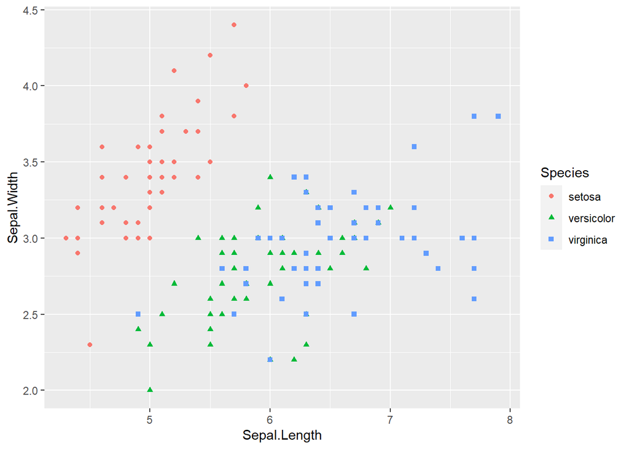

```r
iris %>%
  ggplot(mapping = aes(x = Sepal.Length, y = Sepal.Width)) +
  geom_point(mapping = aes(color = Species,
                           shape = Species))
```

The `scales_*` family of functions allow us to control the behavior of the aesthetics represented **on** the geometric objects.

The default color for categorical or discrete colors is `scale_color_discrete()`.

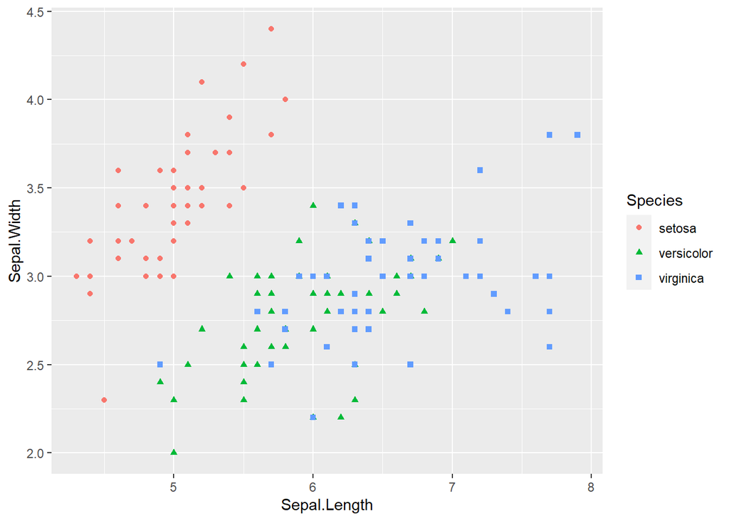

```r
iris %>%
  ggplot(mapping = aes(x = Sepal.Length, y = Sepal.Width)) +
  geom_point(mapping = aes(color = Species,
                           shape = Species)) +
  scale_color_discrete()
```

We can modify the legend title with the first argument to the scale function.

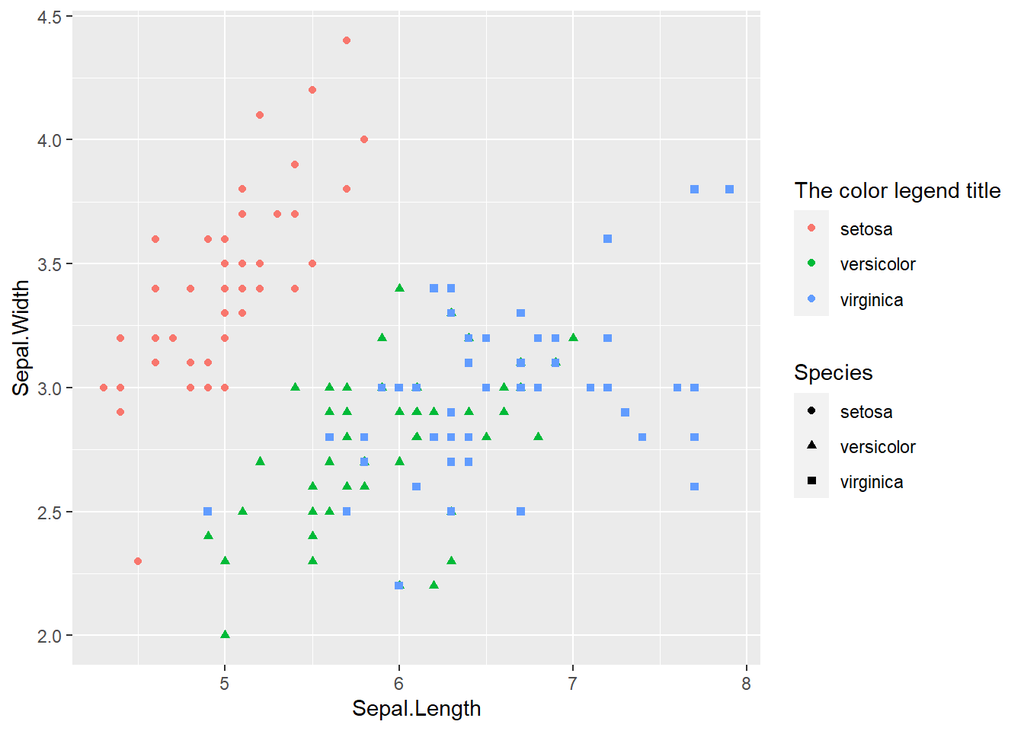

```r
iris %>%
  ggplot(mapping = aes(x = Sepal.Length, y = Sepal.Width)) +
  geom_point(mapping = aes(color = Species,
                           shape = Species)) +
  scale_color_discrete("The color legend title")
```

If the scale legend titles are the same `ggplot()` will try to merge the scale legends together. The default categorical marker shape scale function is `scale_shape_discrete()`.

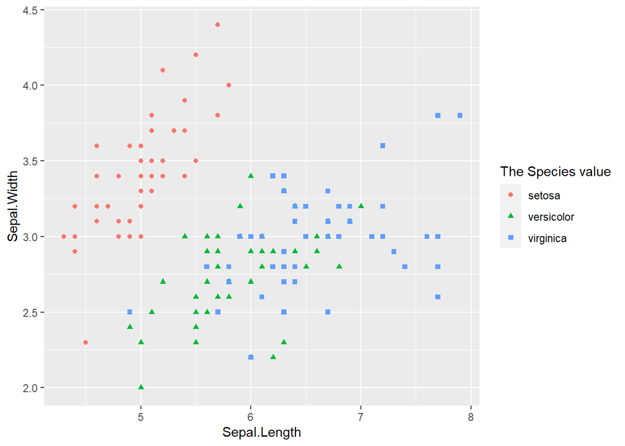

```r
iris %>%
  ggplot(mapping = aes(x = Sepal.Length, y = Sepal.Width)) +
  geom_point(mapping = aes(color = Species,
                           shape = Species)) +
  scale_color_discrete("The Species value") +
  scale_shape_discrete("The Species value")
```

By default the legend is located on the right side of the graphic.

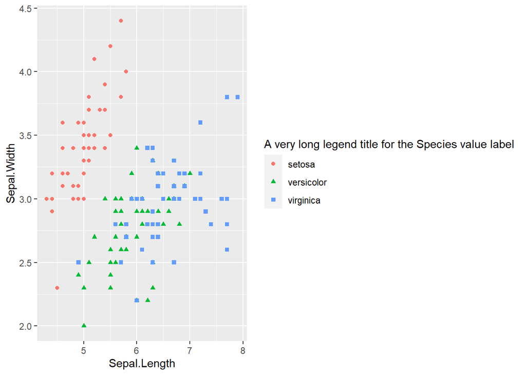

```r
iris %>%
  ggplot(mapping = aes(x = Sepal.Length, y = Sepal.Width)) +
  geom_point(mapping = aes(color = Species,
                           shape = Species)) +
  scale_color_discrete("A very long legend title for the Species value label") +
  scale_shape_discrete("A very long legend title for the Species value label")
```

We can move the legend position using the `theme()` function. Please see the [`theme()` documentation](https://ggplot2.tidyverse.org/reference/theme.html) for more info.

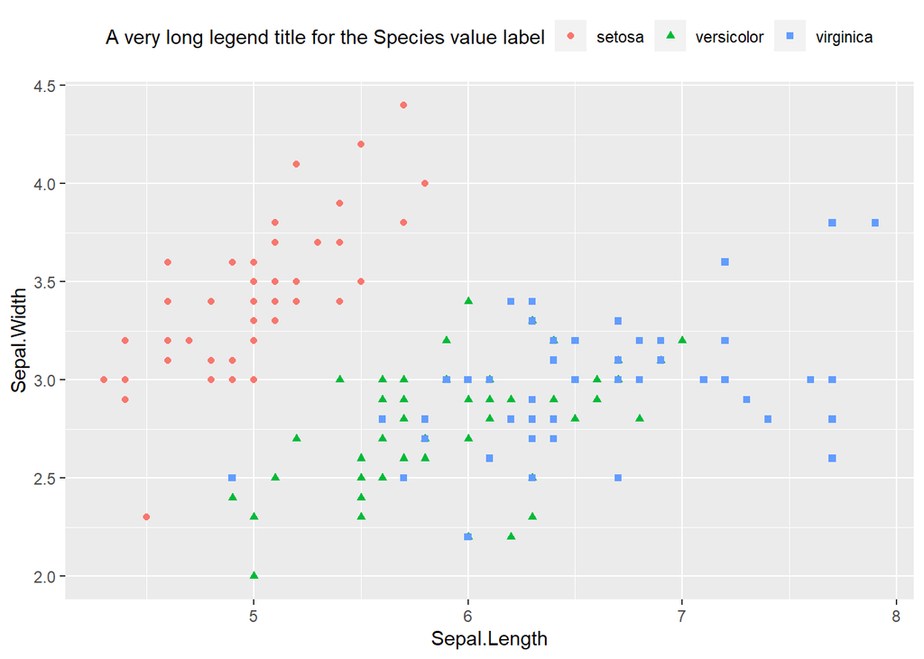

```r
iris %>%
  ggplot(mapping = aes(x = Sepal.Length, y = Sepal.Width)) +
  geom_point(mapping = aes(color = Species,
                           shape = Species)) +
  scale_color_discrete("A very long legend title for the Species value label") +
  scale_shape_discrete("A very long legend title for the Species value label") +
  theme(legend.position = "top")
```

Or we can put the legend at the bottom.

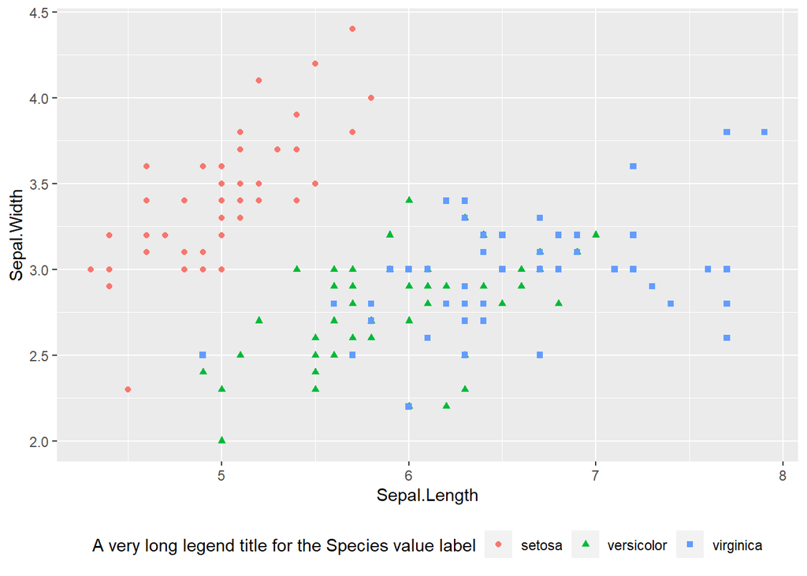

```r
iris %>%
  ggplot(mapping = aes(x = Sepal.Length, y = Sepal.Width)) +
  geom_point(mapping = aes(color = Species,
                           shape = Species)) +
  scale_color_discrete("A very long legend title for the Species value label") +
  scale_shape_discrete("A very long legend title for the Species value label") +
  theme(legend.position = "bottom")
```

But there are some premade default theme “patterns” that we can apply. We saw the `theme_classic()` last week.

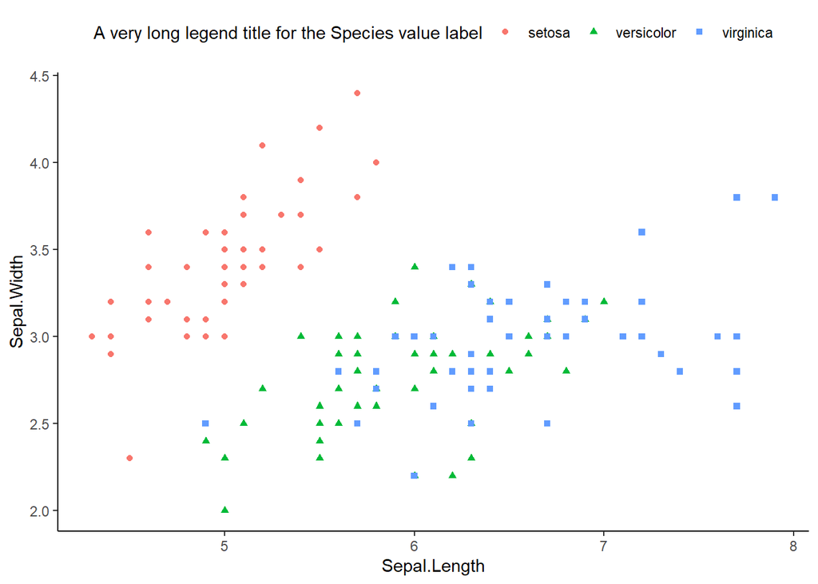

```r
iris %>%
  ggplot(mapping = aes(x = Sepal.Length, y = Sepal.Width)) +
  geom_point(mapping = aes(color = Species,
                           shape = Species)) +
  scale_color_discrete("A very long legend title for the Species value label") +
  scale_shape_discrete("A very long legend title for the Species value label") +
  theme_classic() +
  theme(legend.position = "top")
```

The default theme pattern is “grey”.

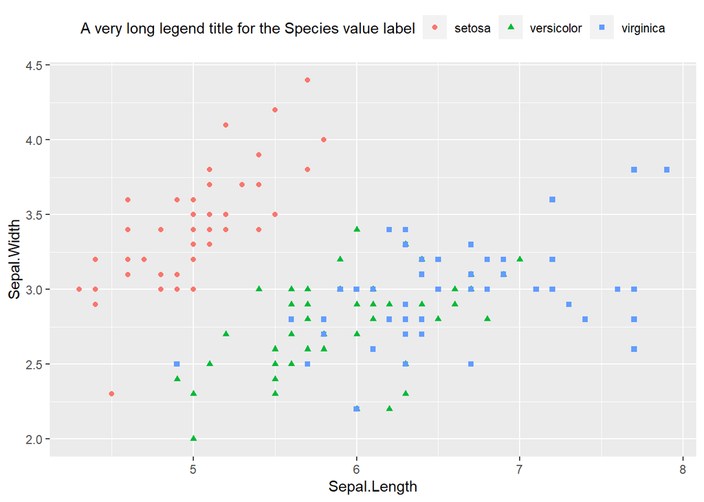

```r
iris %>%
  ggplot(mapping = aes(x = Sepal.Length, y = Sepal.Width)) +
  geom_point(mapping = aes(color = Species,
                           shape = Species)) +
  scale_color_discrete("A very long legend title for the Species value label") +
  scale_shape_discrete("A very long legend title for the Species value label") +
  theme_grey() +
  theme(legend.position = "top")
```

A dark theme.

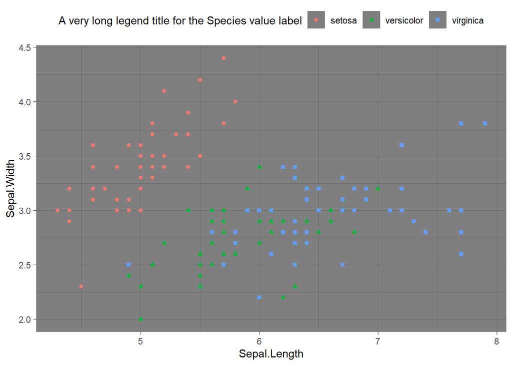

```r
iris %>%
  ggplot(mapping = aes(x = Sepal.Length, y = Sepal.Width)) +
  geom_point(mapping = aes(color = Species,
                           shape = Species)) +
  scale_color_discrete("A very long legend title for the Species value label") +
  scale_shape_discrete("A very long legend title for the Species value label") +
  theme_dark() +
  theme(legend.position = "top")
```

I prefer the black-white theme.

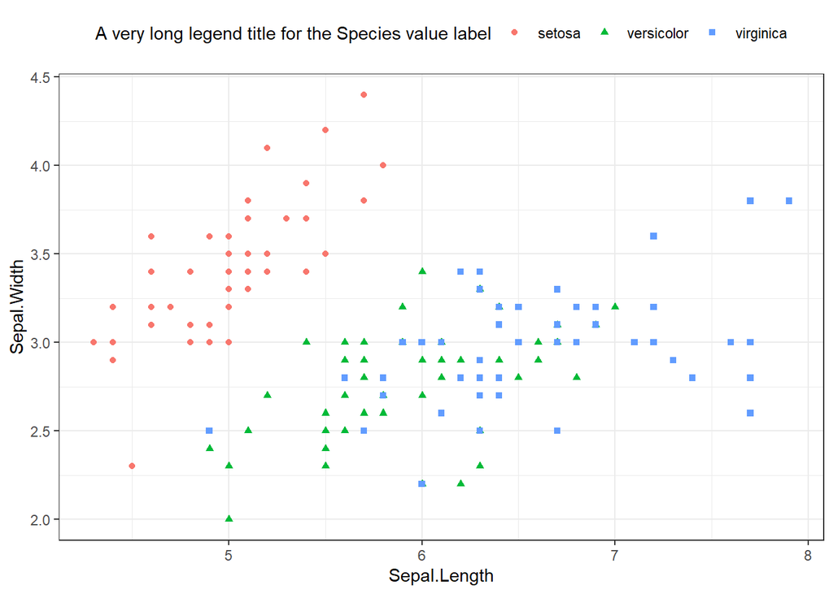

```r
iris %>%
  ggplot(mapping = aes(x = Sepal.Length, y = Sepal.Width)) +
  geom_point(mapping = aes(color = Species,
                           shape = Species)) +
  scale_color_discrete("A very long legend title for the Species value label") +
  scale_shape_discrete("A very long legend title for the Species value label") +
  theme_bw() +
  theme(legend.position = "top")
```

What if we needed to use lighter colors? How would the colors appear on the plot?

With the default discrete color scale, `scale_color_discrete()` we can lighten colors with the *luminance* or `l` argument.

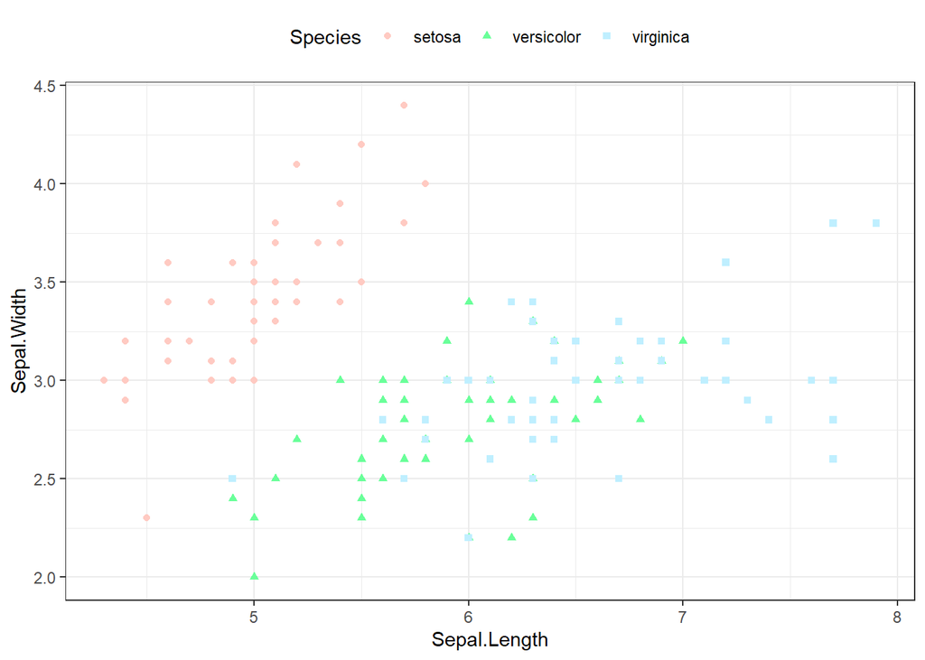

```r
iris %>%
  ggplot(mapping = aes(x = Sepal.Length, y = Sepal.Width)) +
  geom_point(mapping = aes(color = Species,
                           shape = Species)) +
  scale_color_discrete(l = 95) +
  scale_shape_discrete() +
  theme_bw() +
  theme(legend.position = "top")
```

We can further modify the color via the `c` argument or the *chroma* which controls the color intensity.

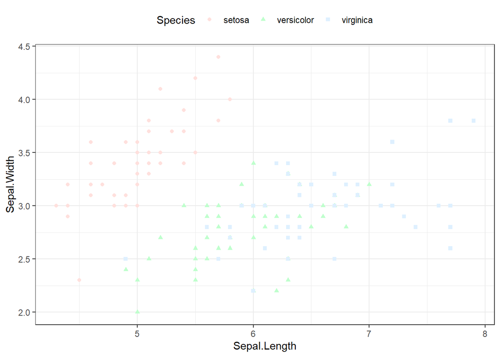

```r
iris %>%
  ggplot(mapping = aes(x = Sepal.Length, y = Sepal.Width)) +
  geom_point(mapping = aes(color = Species,
                           shape = Species)) +
  scale_color_discrete(l = 95,c = 45) +
  scale_shape_discrete() +
  theme_bw() +
  theme(legend.position = "top")
```

If we need to use these kind of very light colors, we want to change to a dark background panel color.

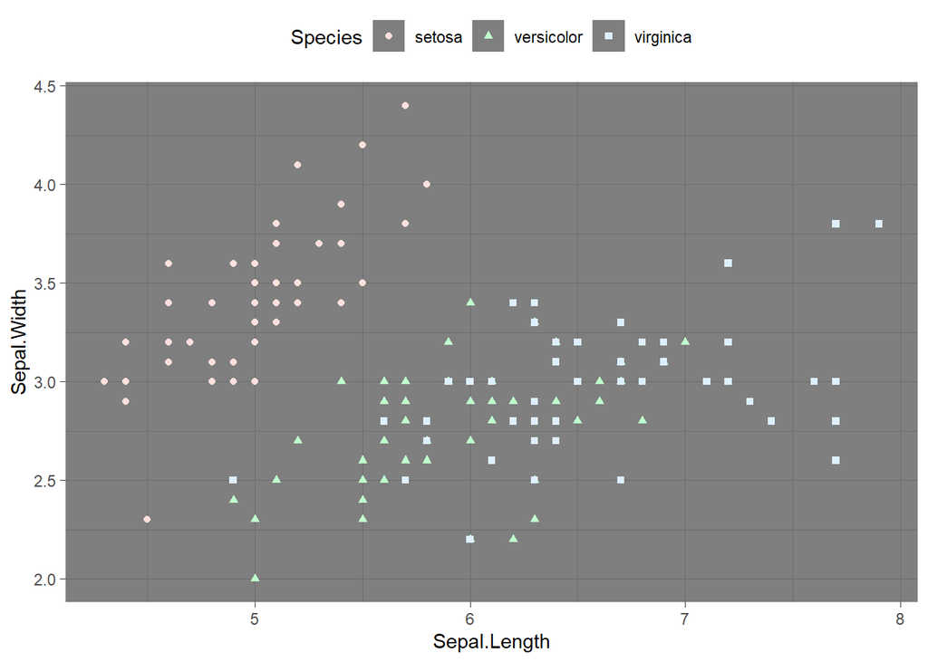

```r
iris %>%
  ggplot(mapping = aes(x = Sepal.Length, y = Sepal.Width)) +
  geom_point(mapping = aes(color = Species,
                           shape = Species)) +
  scale_color_discrete(l = 95,c = 45) +
  scale_shape_discrete() +
  theme_dark() +
  theme(legend.position = "top")
```

I don’t like the default discrete colors. Other color scales exist, some that much better suited for qualtiative or discrete variables. But some of those better scales are limited in the number of colors they can show. When I use the default discrete scale, I tend to make the markers darker because I prefer the white background.

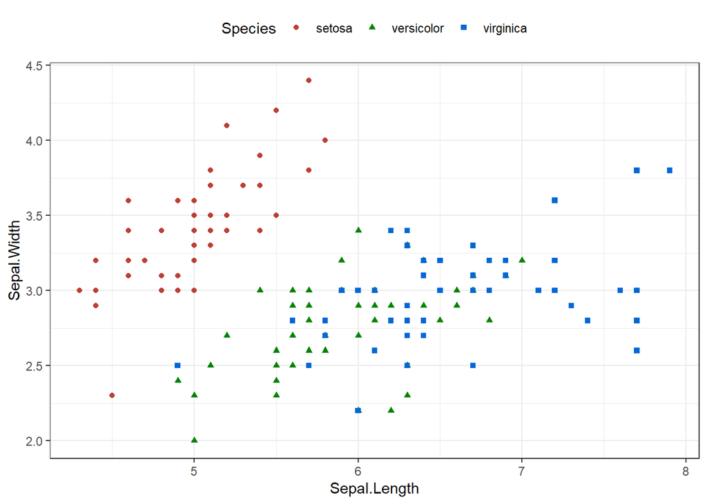

```r
iris %>%
  ggplot(mapping = aes(x = Sepal.Length, y = Sepal.Width)) +
  geom_point(mapping = aes(color = Species,
                           shape = Species)) +
  scale_color_discrete(l = 45) +
  scale_shape_discrete() +
  theme_bw() +
  theme(legend.position = "top")
```

For categorical variable the ColorBrewer scales are quite good. The brewer color schemes are associated with the `scale_color_brewer()` function. Some useful color palettes to consider from Brewer are: Set1, Set2, Pastel1, Accent, and Dark2.

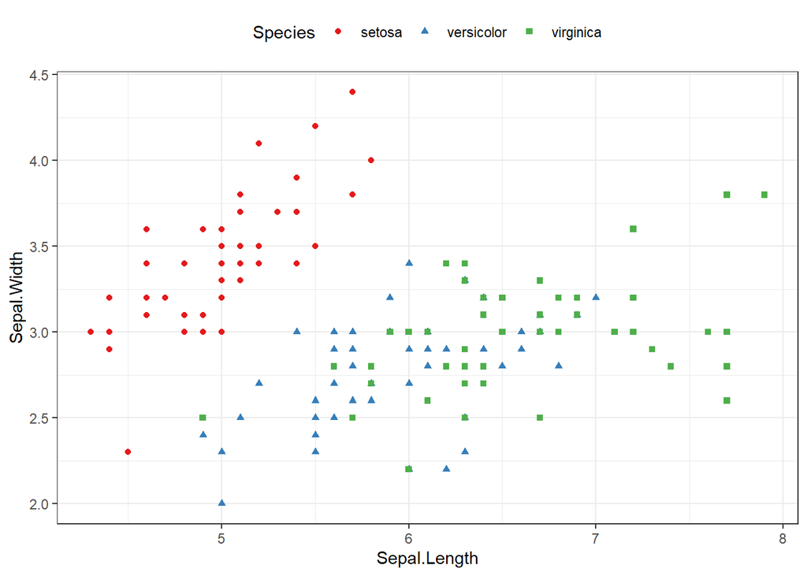

```r
iris %>%
  ggplot(mapping = aes(x = Sepal.Length, y = Sepal.Width)) +
  geom_point(mapping = aes(color = Species,
                           shape = Species)) +
  scale_color_brewer(palette = "Set1") +
  scale_shape_discrete() +
  theme_bw() +
  theme(legend.position = "top")
```

Examine other Brewer palettes.

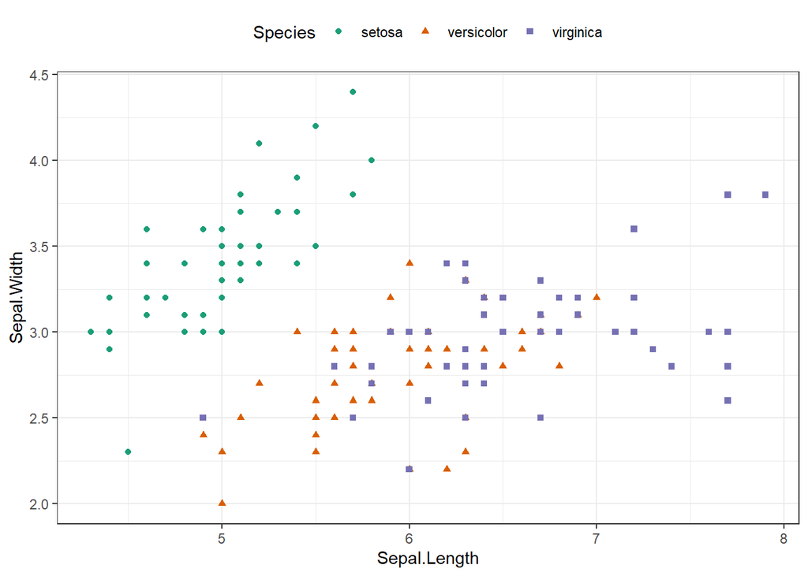

```r
iris %>%
  ggplot(mapping = aes(x = Sepal.Length, y = Sepal.Width)) +
  geom_point(mapping = aes(color = Species,
                           shape = Species)) +
  scale_color_brewer(palette = "Dark2") +
  scale_shape_discrete() +
  theme_bw() +
  theme(legend.position = "top")
```

The [brewer documentation](https://ggplot2.tidyverse.org/reference/scale_brewer.html)

The previous color palettes are not color blind safe. But that’s where the `ggthemes` package helps out and we saw the colorblind friendly palette last week.

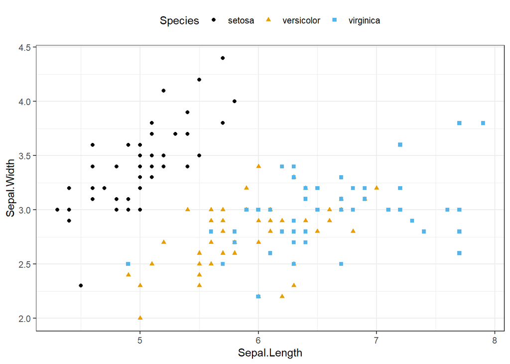

```r
iris %>%
  ggplot(mapping = aes(x = Sepal.Length, y = Sepal.Width)) +
  geom_point(mapping = aes(color = Species,
                           shape = Species)) +
  ggthemes::scale_color_colorblind() +
  scale_shape_discrete() +
  theme_bw() +
  theme(legend.position = "top")
```

## Marker shape

A quick way to change the type of shape is to go from a SOLID to an OPEN shape. This is controlled by the default `scale_shape_discrete()` argument `solid`.

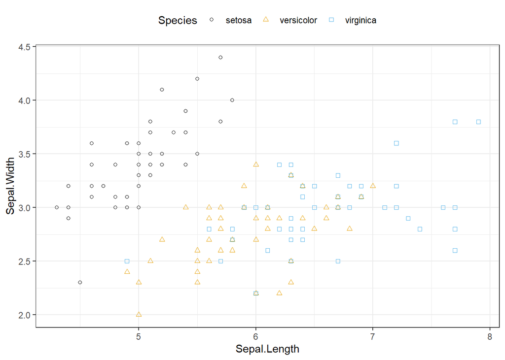

```r
iris %>%
  ggplot(mapping = aes(x = Sepal.Length, y = Sepal.Width)) +
  geom_point(mapping = aes(color = Species,
                           shape = Species)) +
  ggthemes::scale_color_colorblind() +
  scale_shape_discrete(solid = FALSE) +
  theme_bw() +
  theme(legend.position = "top")
```

Let’s make the sizes bigger.

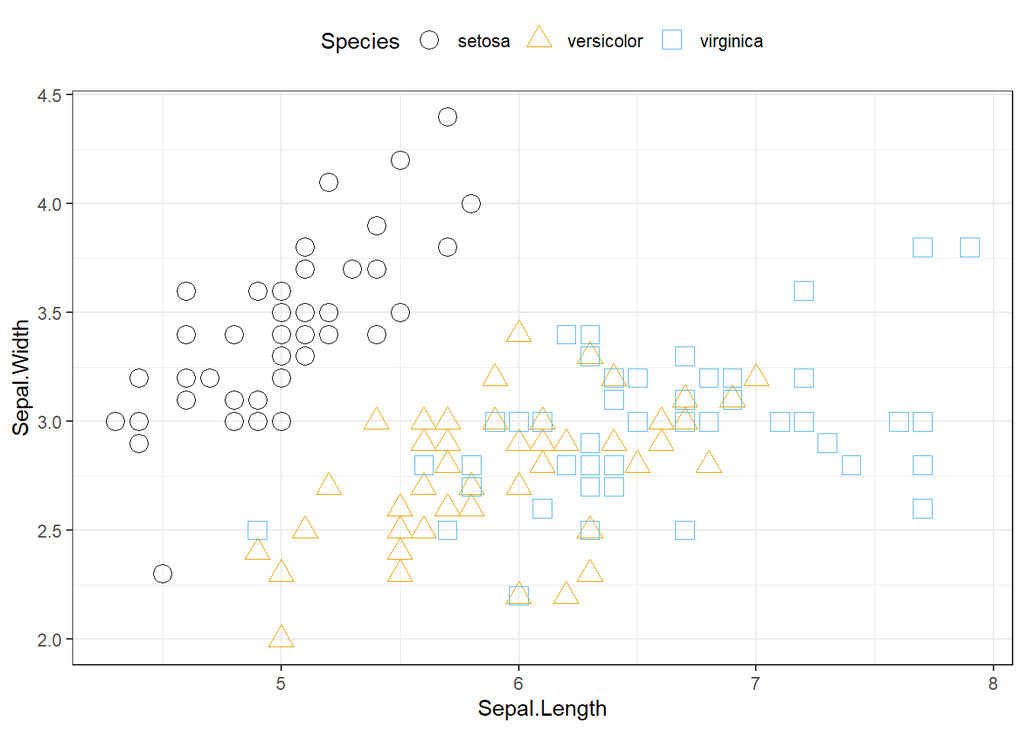

```r
iris %>%
  ggplot(mapping = aes(x = Sepal.Length, y = Sepal.Width)) +
  geom_point(mapping = aes(color = Species,
                           shape = Species),
             size = 4) +
  ggthemes::scale_color_colorblind() +
  scale_shape_discrete(solid = FALSE) +
  theme_bw() +
  theme(legend.position = "top")
```

Compare with the solid shape.

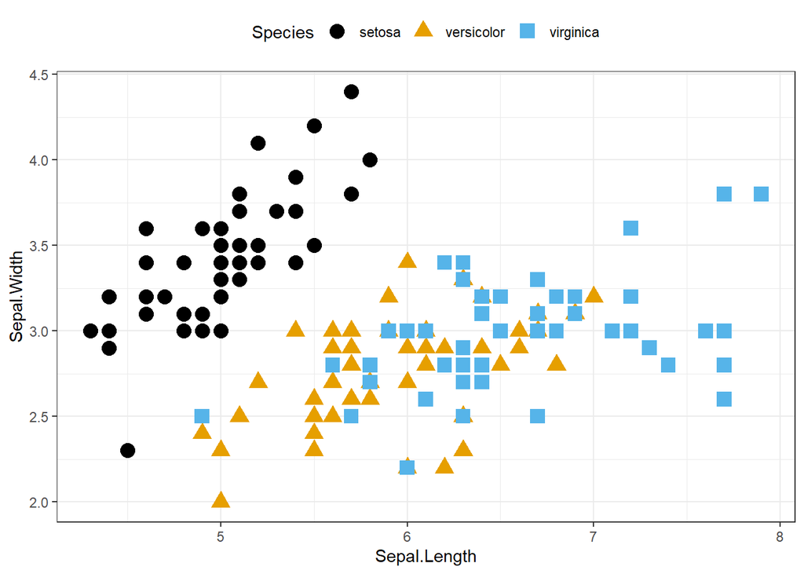

```r
iris %>%
  ggplot(mapping = aes(x = Sepal.Length, y = Sepal.Width)) +
  geom_point(mapping = aes(color = Species,
                           shape = Species),
             size = 4) +
  ggthemes::scale_color_colorblind() +
  scale_shape_discrete(solid = TRUE) +
  theme_bw() +
  theme(legend.position = "top")
```

## transparency

The marker transparency can help us “see” if there are multiple observations located at the same set of `x` and `y` aesthetic positions. The transparency is controlled by `alpha`. A value of `alpha = 0.5` means that it takes 2 observations directly on top of each other to yield an opague marker.

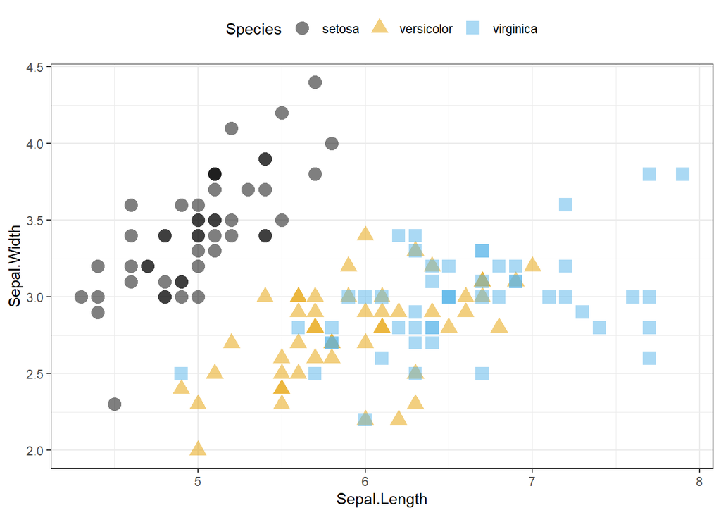

```r
iris %>%
  ggplot(mapping = aes(x = Sepal.Length, y = Sepal.Width)) +
  geom_point(mapping = aes(color = Species,
                           shape = Species),
             size = 4,
             alpha = 0.5) +
  ggthemes::scale_color_colorblind() +
  scale_shape_discrete(solid = TRUE) +
  theme_bw() +
  theme(legend.position = "top")
```

If we use a very low value of `alpha`, such as `alpha=0.1` we need 10 observations directly on top of each other to have a fully opague point.

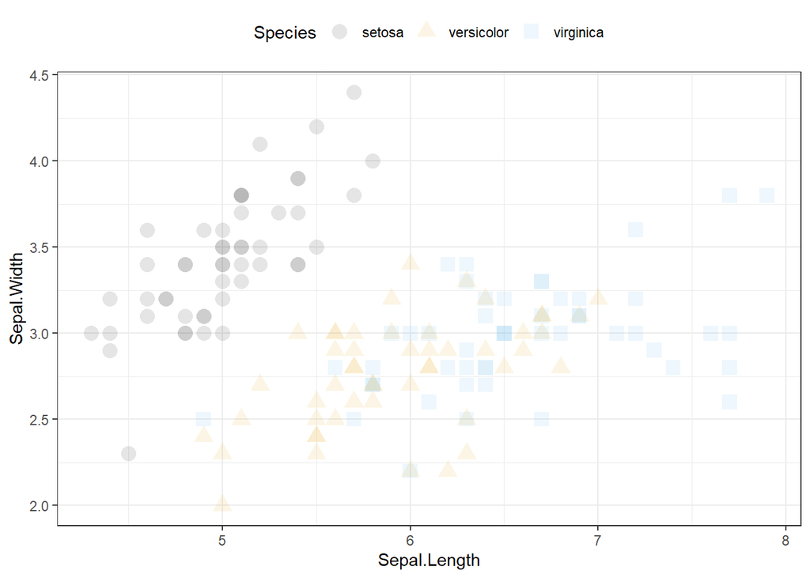

```r
iris %>%
  ggplot(mapping = aes(x = Sepal.Length, y = Sepal.Width)) +
  geom_point(mapping = aes(color = Species,
                           shape = Species),
             size = 4,
             alpha = 0.1) +
  ggthemes::scale_color_colorblind() +
  scale_shape_discrete(solid = TRUE) +
  theme_bw() +
  theme(legend.position = "top")
```

May consider alpha of 0.33.

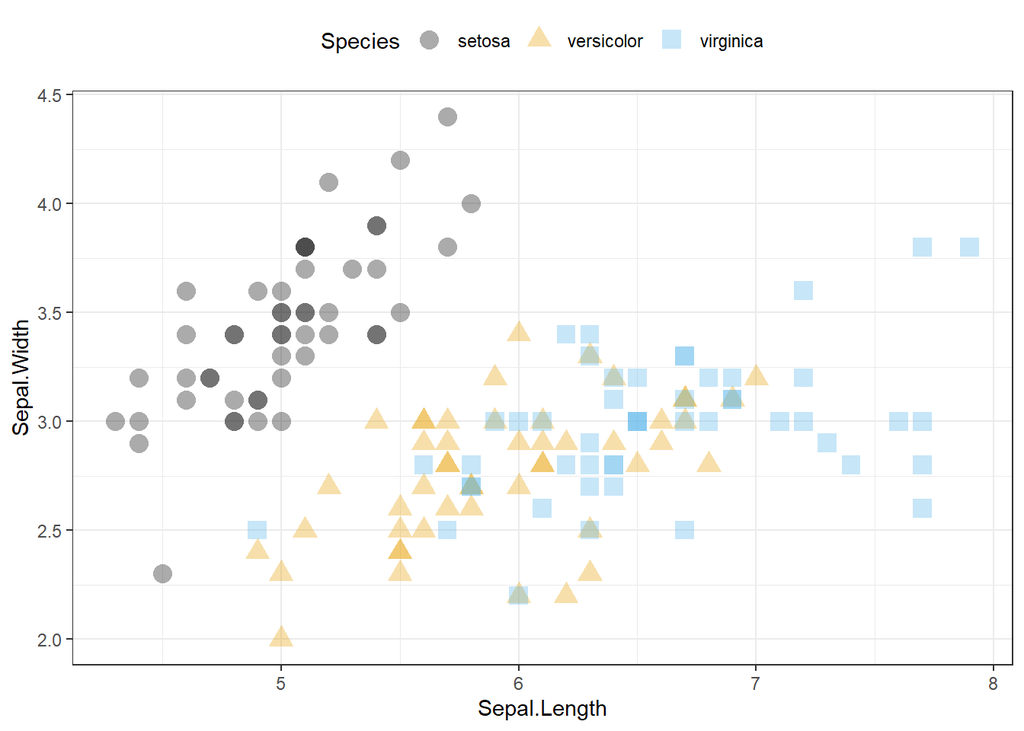

```r
iris %>%
  ggplot(mapping = aes(x = Sepal.Length, y = Sepal.Width)) +
  geom_point(mapping = aes(color = Species,
                           shape = Species),
             size = 4,
             alpha = 0.33) +
  ggthemes::scale_color_colorblind() +
  scale_shape_discrete(solid = TRUE) +
  theme_bw() +
  theme(legend.position = "top")
```

We can look up the various aesthetics associated with each type of geometric object.

[Aesthetics specifications](https://ggplot2.tidyverse.org/articles/ggplot2-specs.html)

### Points with color and fill

The `fill` is associated with “filling a region or area with color”. Think of painting a rectangle. The `color` aesthetic is associated with applying color to a **point** in space. ggplot2 says we use a “color stroke”. Color is associated with points and lines, while fill is associated with polygons/regions/areas.  
We can use points that have both color and fill if we want to use effectively 2 separate color scales. One for the point color stroke and one for the area region fill.

Use the marker fill, color, and shape to denote `Species`. So we are using three distinct aesthetics for one variable. To force the shapes with both fill and color, we will use the `scale_shape_manual()` function. Any of the `scale_*_manual()` functions give us the fine tune control to show exactly what we want. We specify the `values` as a named vector.

Use marker shapes 21, 24, and 25.

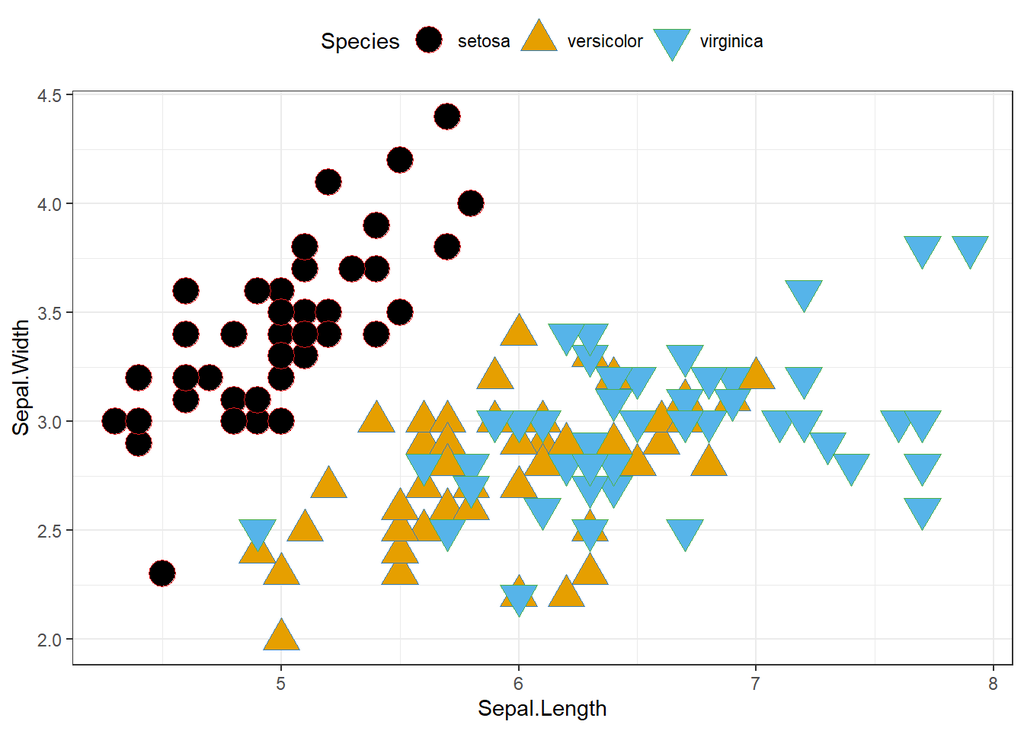

```r
iris %>%
  ggplot(mapping = aes(x = Sepal.Length, y = Sepal.Width)) +
  geom_point(mapping = aes(color = Species,
                           fill = Species,
                           shape = Species),
             size = 6,
             alpha = 1.0) +
  ggthemes::scale_fill_colorblind() +
  scale_color_brewer(palette = "Set1") +
  scale_shape_manual(values = c("setosa" = 21,
                                "versicolor" = 24,
                                "virginica" = 25)) +
  theme_bw() +
  theme(legend.position = "top")
```

We can control the “size” of the color stroke with the `stroke` argument for points that have both fill and color.

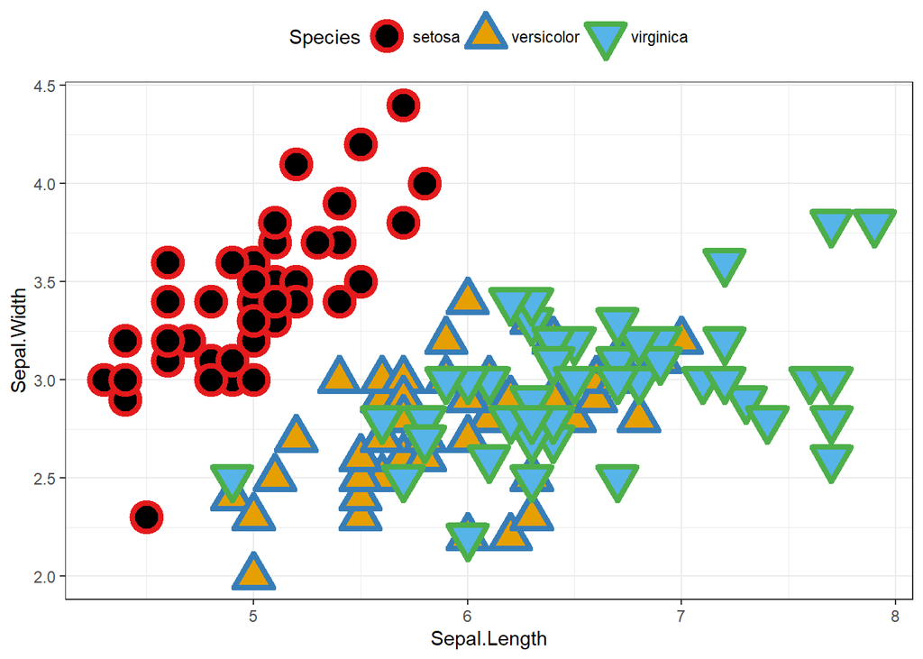

```r
iris %>%
  ggplot(mapping = aes(x = Sepal.Length, y = Sepal.Width)) +
  geom_point(mapping = aes(color = Species,
                           fill = Species,
                           shape = Species),
             size = 6,
             alpha = 1.0,
             stroke = 2.25) +
  ggthemes::scale_fill_colorblind() +
  scale_color_brewer(palette = "Set1") +
  scale_shape_manual(values = c("setosa" = 21,
                                "versicolor" = 24,
                                "virginica" = 25)) +
  theme_bw() +
  theme(legend.position = "top")
```

We can apply a manual color scale if we would like. Here’s a [list of the names](http://sape.inf.usi.ch/quick-reference/ggplot2/colour) of colors we can type in.

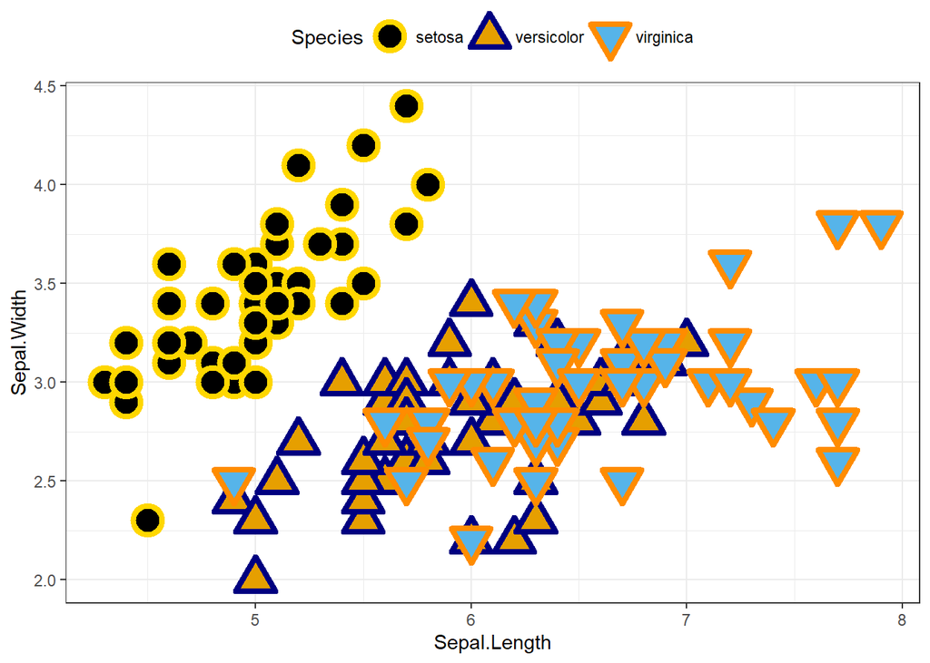

```r
iris %>%
  ggplot(mapping = aes(x = Sepal.Length, y = Sepal.Width)) +
  geom_point(mapping = aes(color = Species,
                           fill = Species,
                           shape = Species),
             size = 6,
             alpha = 1.0,
             stroke = 2.25) +
  ggthemes::scale_fill_colorblind() +
  scale_color_manual(values = c("setosa" = 'gold',
                                'versicolor' = 'navyblue',
                                'virginica' = 'darkorange')) +
  scale_shape_manual(values = c("setosa" = 21,
                                "versicolor" = 24,
                                "virginica" = 25)) +
  theme_bw() +
  theme(legend.position = "top")
```

## Facets

The last major component is the **facet** or *subplot*. Maybe we want to compare the relationship of variables across groups where the groups are represented by separate subplots. It’s common to consider creating subplots with for-loops. We loop over an interating variable and that iterating variable controls how we subset the data to create the visual in each subplot.

Controlling the subplot based on a variable means there is a variable in the data set that dictages how we **view** the data. A facet is a “window” is a particular view to a subset of the larger data set. The grammar of graphics considers facets (subplots) as an integral part of creating a visualization to graphically communicate relationships in our data.

In `ggplot2`, the facets are specifed by the `facet_` family of functions **outside** of the geometric objects. Let’s include the `Species` as facets where the facets are “wrapped”.

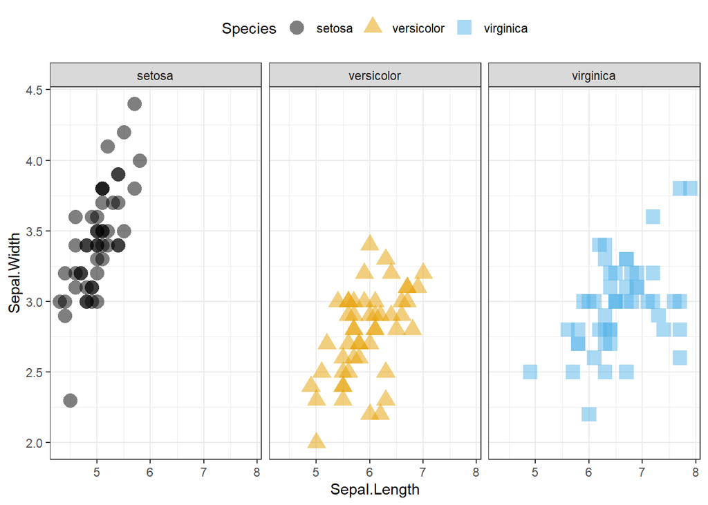

```r
iris %>%
  ggplot(mapping = aes(x = Sepal.Length, y = Sepal.Width)) +
  geom_point(mapping = aes(color = Species,
                           shape = Species),
             size = 4.5, alpha = 0.5) +
  facet_wrap( ~ Species ) +
  ggthemes::scale_color_colorblind() +
  scale_shape_discrete() +
  theme_bw() +
  theme(legend.position = "top")
```

In this case, since the marker shape and the marker color stroke also correspond to the facet variable, let’s turn off the legend.

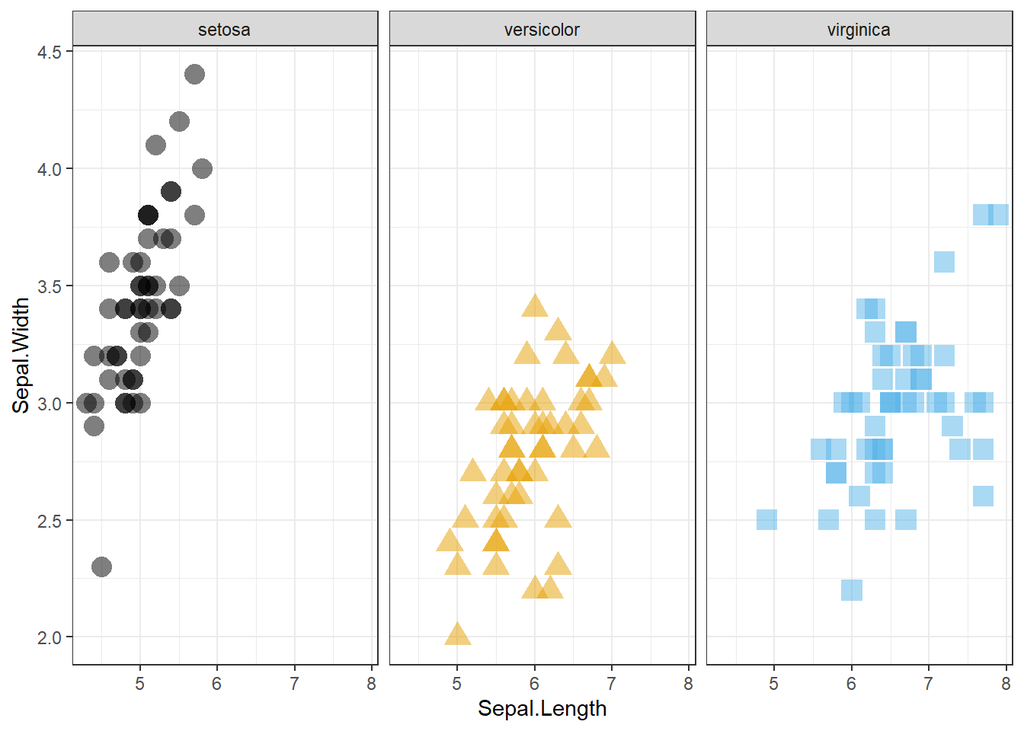

```r
iris %>%
  ggplot(mapping = aes(x = Sepal.Length, y = Sepal.Width)) +
  geom_point(mapping = aes(color = Species,
                           shape = Species),
             size = 4.5, alpha = 0.5) +
  facet_wrap( ~ Species ) +
  ggthemes::scale_color_colorblind(guide = FALSE) +
  scale_shape_discrete(guide = FALSE) +
  theme_bw() +
  theme(legend.position = "top")
```